# Data needs for Spike and Slab Mixed-Effects Location Scale Model

Marwin Carmo

## Background

- The SS-MELSM is a method to identify clusters (such as students, classrooms, schools, etc.) that display unusual amounts of residual variability.
- The MELSM allows the simultaneous estimation of a model for the means (location) and a model for the residual variance (scale).
- The spike and slab prior serves as Bayesian regularization technique to shrink random effects to their fixed effect.

## Motivation

- SS-MELSM can be implemented with the `ivd` package for `R`.
- The model was illustrated with a real dataset of 160 schools and 11,386 students.
- **Goal**: Determine the minimum sample size and observations per cluster needed for stable estimates of scale random effects standard deviation.

## Data generating mechanism

$$\begin{equation}
\label{eq:model-1}
\begin{aligned}
y_{ij} & \sim \mathcal{N}(\mu_j, \sigma_j)\\
\mu_j &= \gamma_{0} + u_{0j}\\
\sigma_j &= \exp(\eta_{0} + t_{0j}).
\end{aligned}
\end{equation}$$

$$\begin{equation}
\textbf{v}=
\begin{bmatrix} u_0 \\ t_0 \end{bmatrix} \sim \mathcal{N}
\begin{pmatrix}
\boldsymbol{0}=
\begin{bmatrix} 0 \\ 0 \end{bmatrix},
\boldsymbol{\Sigma}=
\begin{bmatrix} \tau^2_{u_0} & \tau_{u_0t_0} \\
\tau_{u_0t_0} & \tau^2_{t_0}
\end{bmatrix}
\end{pmatrix}
\end{equation}$$

## Simulation design

$$\begin{equation}
\label{eq:model-1b}
\begin{aligned}
y_{ij} & \sim \mathcal{N}(\mu_j, \sigma_j)\\
\mu_j &= 0 + u_{0j}\\
\sigma_j &= \exp(0 + t_{0j}).
\end{aligned}
\end{equation}$$

$$\begin{equation}
\textbf{v}=
\begin{bmatrix} u_0 \\ t_0 \end{bmatrix} \sim \mathcal{N}
\begin{pmatrix}
\boldsymbol{0}=
\begin{bmatrix} 0 \\ 0 \end{bmatrix},
\boldsymbol{\Sigma}=
\begin{bmatrix} 0.1089 & -0.0039 \\
-0.0039 & 0.0081
\end{bmatrix}
\end{pmatrix}
\end{equation}$$

$\Sigma$ is estimated from a real dataset included in `ivd` as `saeb`.

| Scenario | Number of Schools | Students per school | Total students |
| --- | --- | --- | --- |
| 1. Small | 50 | 20 | 1,000 |
| 2. Small | 50 | 50 | 2,500 |
| 3. Medium | 100 | 30 | 3,000 |
| 4. Medium | 100 | 100 | 10,000 |
| 5. Large | 200 | 30 | 6,000 |
| 6. Large | 200 | 100 | 20,000 |
| 7. Extra large | 500 | 50 | 25,000 |
| 8. Extra large | 500 | 100 | 50,000 |

- The number of schools and students were set to reflect realistic data structures:
  - Rural areas, urban areas, or national assessments.
- All models were fitted with four chains of 2,000 iterations and 8,000 warm-up samples.
- Each scenario was replicated 100 times.
- `R` 4.4.2 was used for the analyses.
- Metrics of Bias, MSE, and coverage were computed.

## Results

- Total runtime was approximately 20 hours.
- Scenario 8 could not be estimated due to exceeding the memory limit (>64GB).
- The convergence rate across all scenarios was about 80%.

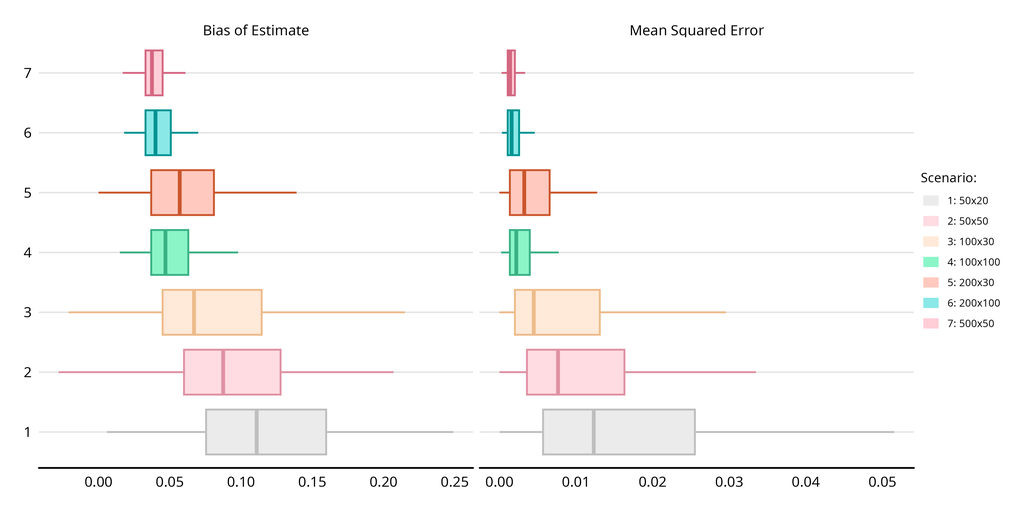

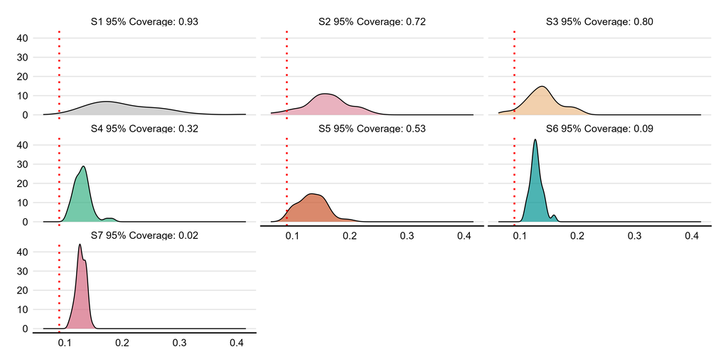

### Number of schools with unnusual residual variability

| Scenario | Schools | Students/School | Total | PIP > 0.75 (%) |
| --- | --- | --- | --- | --- |
| 1 | 50 | 20 | 1,000 | 2.0 |
| 2 | 50 | 50 | 2,500 | 7.7 |
| 3 | 100 | 30 | 3,000 | 3.7 |
| 4 | 100 | 100 | 10,000 | 18.0 |
| 5 | 200 | 30 | 6,000 | 4.3 |
| 6 | 200 | 100 | 20,000 | 18.3 |
| 7 | 500 | 50 | 25,000 | 8.7 |

### Efficiency metrics

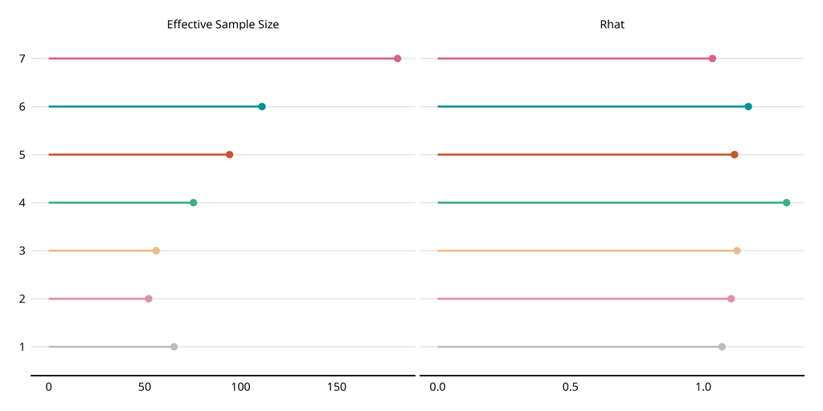